# Adjusted WdStar Application - Immune Pathways

Lauren Fanning

2026-03-05

```r
library(readxl)
library(glue)
library(dplyr)
```

# 1 Introduction

This application is a use-case example for variable adjustment for the $W_d^*$ test statistic, a robust multivariate analysis of variance test (https://microbiomejournal.biomedcentral.com/articles/10.1186/s40168-019-0659-9).

Samples were provided by 83 participants from three completed epidemiological studies, listed in the main text. Total RNA was extracted from formalin-fixed, paraffin-embedded (FFPE) tissue and immune gene expression was determined using the NanoString nCounter platform. Count data were normalized using the RUVg methodology (https://bioconductor.org/packages//release/bioc/vignettes/RUVSeq/inst/doc/RUVSeq.html). Immune pathways were defined by groups of their associated genes, as provided by the NanoString Immune v2. panel, ranging from 11 to 259 genes per pathway. The first ten pathways listed in the immune panel were used for this example: Adaptive Immune System (141 genes), Apoptosis (54 genes), Autophagy (11 genes), B-cell Receptor Signaling (35 genes), Cell Adhesion (60 genes), Chemokine Signaling (63), Complement System (39 genes), Cytokine Signaling (259 genes), Hemostasis (73 genes), and Host-pathogen Interaction (252 genes).

Expression of ten immune pathways were contrasted across BMI categories, per CDC guidelines: BMI < 25 considered Normal, BMI between 25 and 29 considered Overweight, and BMI of 30 or greater considered Obese. There were no underweight participants (BMI < 18.5) in this cohort. Unadjusted and adjusted $W_d^*$ tests were performed. The adjusted model included patient age, sex (female, male), and lesion histologic type (SSP, Tubular, Tubulovillous, Villous). These adjustment covariates were chosen for their clinical relevance and potential to distort the association between pathway expression and BMI category. It is important to adjust analyses, when able and applicable, to minimize bias in your results and to capture a more accurate estimate for the association between independent and dependent variables.

## 1.1 Data view

```r
#load("ImmuneApplication.RData")
```

Included in the RData file are: 1. a dataframe in which rows are subjects and columns are demographic variables (e.g., age, sex, BMI category), clinical variables (e.g., histologic type), and RUVg-normalized gene count data (one column per gene).

```r
pathway_data[1:5, 1:5]
```

```
##   age    sex    bmi_cat histology     ABL1
## 1  69   Male Overweight   Tubular 7.947025
## 2  56 Female     Normal       SSP 7.660410
## 3  51 Female      Obese       SSP 7.126629
## 4  50 Female Overweight   Tubular 7.999901
## 5  52 Female     Normal   Tubular 7.385678
```

2. a table where rows are genes and columns are pathways, indicating which genes are associated with each pathway, denoted by an ‘x’, otherwise NA. Note: genes are subject to be associated with multiple pathways.

```r
gene_pathway_association[11:20,1:5]
```

```
## # A tibble: 10 × 5
##    `Gene list` Adaptive Immune Syst…¹ Apoptosis Autophagy B cell Receptor Sign…²
##    <chr>       <chr>                  <chr>     <chr>     <chr>
##  1 ATM         <NA>                   x         <NA>      <NA>
##  2 B2M         x                      <NA>      <NA>      <NA>
##  3 BATF        <NA>                   <NA>      <NA>      <NA>
##  4 BAX         <NA>                   x         <NA>      <NA>
##  5 BCAP31      x                      x         <NA>      <NA>
##  6 BCL10       x                      <NA>      <NA>      x
##  7 BCL2        <NA>                   x         x         <NA>
##  8 BCL2L11     <NA>                   x         <NA>      <NA>
##  9 BCL6        <NA>                   <NA>      <NA>      <NA>
## 10 BID         <NA>                   x         <NA>      <NA>
## # ℹ abbreviated names: ¹`Adaptive Immune System`, ²`B cell Receptor Signaling`
```

3. a list that shows which genes are associated with each pathway

```r
pathways_with_genes[3:4]
```

```
## $Autophagy
##  [1] "ATG10"   "ATG12"   "ATG16L1" "ATG5"    "ATG7"    "BCL2"    "HRAS"
##  [8] "MAPK1"   "PRKCD"   "RAF1"    "TRAF6"
##
## $`B cell Receptor Signaling`
##  [1] "BCL10"  "BLNK"   "BTK"    "CD19"   "CD22"   "CD79A"  "CD79B"  "CD81"
##  [9] "CHUK"   "CR2"    "FCGR2B" "FYN"    "HRAS"   "IFITM1" "IKBKB"  "IKBKG"
## [17] "LILRB3" "MALT1"  "MAPK1"  "NFATC1" "NFATC2" "NFATC3" "NFKB1"  "NFKBIA"
## [25] "PSMB10" "PSMB5"  "PSMB7"  "PSMB8"  "PSMB9"  "PSMC2"  "PSMD7"  "PTPN6"
## [33] "RAF1"   "RELA"   "SYK"
```

4. character lists of pathways

```r
pathways[1:5]
```

```
## [1] "Adaptive Immune System"    "Apoptosis"
## [3] "Autophagy"                 "B cell Receptor Signaling"
## [5] "Cell Adhesion"
```

Note: the dataframe (object 1) is the only data object necessary to perform the $W_d^*$ test. All other data objects are specific to this example.

## 1.2 $W_d^*$ installation

```r
#devtools::install_github("alekseyenko/WdStar", ref="sandbox", subdir = "pkg", force=T)
library(WdStar)
```

# 2 Immune Pathway Analysis

## 2.1 Specifications

Two elements that may be helpful to specify beforehand are 1) your independent variable (which must be a factor variable) and 2) the formula containing the variables you would like to adjust for. Note: do not include your independent variable in the formula, this will remove any effect of this variable on the outcome. The formula must be formatted as ~ variable1 + variable2 + variable3. The adjustment variables can be continuous or categorical but the independent variable must be categorical.

```r
pathway_data$bmi_cat <- as.factor(pathway_data$bmi_cat)

formula <- ~ age + sex + histology
```

## 2.2 Simple Application

First, application of WdS.test() is shown for genes within one pathway (Adaptive Immune System). The list of applicable genes and their corresponding columns in the dataframe for this pathway are extracted. An unadjusted distance matrix is calculated, then unadjusted and adjusted $W_d^*$ are performed for the selected pathway. Notice that the WdS test statistic decreases from 1.3 to 0.91 after adjustment.

```r
genes_for_pathway = pathways_with_genes[[1]]

gene_data = pathway_data[, genes_for_pathway]

distance_matrix = dist(gene_data, method="euclidean")

WdS.test(dm=distance_matrix, f=pathway_data$bmi_cat, nrep=999, strata=NULL)
```

```
##
##  Distance-based Multivariate Welch ANOVA
##
## data:  euclidean distance matrix with 83 observations and grouping factor with 3 levels
## WdS = 1.3057, dfb = 2, number of permutations = 999, p-value = 0.157
## sample estimates:
## Omega squared (ω²) effect size
##                    0.007311784
```

```r
WdS.test(dm=distance_matrix, f=pathway_data$bmi_cat, formula = formula, formula_data = pathway_data)
```

```
##
##  Adjusted Distance-based Multivariate Welch ANOVA
##
## data:  euclidean distance matrix with 83 observations and grouping factor with 3 levels
## WdS = 0.91216, formula = formula with 3 terms, dfb = 2 , number of
## permutations = 999 , p-value = 0.517
## sample estimates:
## Omega squared (ω²) effect size
##                    -0.00212106
```

## 2.3 $W_d^*$ loop for all pathways

The following loop performs unadjusted and adjusted $W_d^*$ for all 10 pathways and combines the results into one dataframe.

```r
WdS_results_unadjusted = data.frame(
  Pathway = character(),
  "Wd_statistic_unadjusted" = double(),
  "Wd_p_value_unadjusted" = double(),
  "Omega2_unadjusted" = double(),
  stringsAsFactors = FALSE
)

WdS_results_adjusted = data.frame(
  Pathway = character(),
  "Wd_statistic_adjusted" = double(),
  "Wd_p_value_adjusted" = double(),
  "Omega2_adjusted" = double(),
  stringsAsFactors = FALSE
)

pathway_count = 1

for (pathway in pathways) {

  genes_for_pathway = pathways_with_genes[[pathway]]

  gene_data = pathway_data[, genes_for_pathway]

  distance_matrix = dist(gene_data, method="euclidean")

  test_result = WdS.test(dm=distance_matrix, f=pathway_data$bmi_cat, nrep=999, strata=NULL)
  WdS_results_unadjusted = WdS_results_unadjusted %>%
    add_row(
      Pathway = pathway,
      Wd_statistic_unadjusted = test_result$statistic,
      Wd_p_value_unadjusted = test_result$p.value,
      Omega2_unadjusted = test_result$estimate
    )

  test_result_adjusted = WdS.test(dm=distance_matrix, f=pathway_data$bmi_cat, formula = formula, formula_data = pathway_data)
  WdS_results_adjusted = WdS_results_adjusted %>%
    add_row(
      Pathway = pathway,
      Wd_statistic_adjusted = test_result_adjusted$statistic,
      Wd_p_value_adjusted = test_result_adjusted$p.value,
      Omega2_adjusted = test_result_adjusted$estimate
    )
  pathway_count = pathway_count + 1
  print(glue("Pathway: {pathway} ({pathway_count}/{length(pathways)})"))
}
```

```
## Pathway: Adaptive Immune System (2/10)
## Pathway: Apoptosis (3/10)
## Pathway: Autophagy (4/10)
## Pathway: B cell Receptor Signaling (5/10)
## Pathway: Cell Adhesion (6/10)
## Pathway: Chemokine Signaling (7/10)
## Pathway: Complement System (8/10)
## Pathway: Cytokine Signaling (9/10)
## Pathway: Hemostasis (10/10)
## Pathway: Host-pathogen Interaction (11/10)
```

```r
WdS_pathway_results = dplyr::bind_cols(WdS_results_unadjusted, WdS_results_adjusted[, -1])
head(WdS_pathway_results)
```

```
##                     Pathway Wd_statistic_unadjusted Wd_p_value_unadjusted
## 1    Adaptive Immune System                1.305674                 0.181
## 2                 Apoptosis                1.474296                 0.129
## 3                 Autophagy                1.842642                 0.080
## 4 B cell Receptor Signaling                1.385558                 0.168
## 5             Cell Adhesion                1.213341                 0.235
## 6       Chemokine Signaling                1.273048                 0.171
##   Omega2_unadjusted Wd_statistic_adjusted Wd_p_value_adjusted Omega2_adjusted
## 1       0.007311784             0.9121623               0.524   -2.121060e-03
## 2       0.011299668             0.9998139               0.377   -4.484475e-06
## 3       0.019900562             1.1936748               0.287    4.645185e-03
## 4       0.009205046             0.9200361               0.477   -1.930561e-03
## 5       0.005114453             0.7793208               0.638   -5.345998e-03
## 6       0.006536463             0.9267221               0.490   -1.768857e-03
```

## 2.4 Alternative coding for adjusted $W_d^*$

Alternatively, the adjusted $W_d^*$ test may be performed by adjusting the distance matrix prior to conducting the test. Here, we use a.dist() to adjust the distance matrix used in WdS.test(), specifying the unadjusted matrix (distance_matrix), the formula listing the variables to adjust for, and the corresponding dataframe. Using an adjusted distance matrix within WdS.test() yields the same results as specifying a formula within WdS.test(), shown earlier.

```r
formula <- ~ age + sex + histology

genes_for_pathway = pathways_with_genes[[1]]

gene_data = pathway_data[, genes_for_pathway]

distance_matrix = dist(gene_data, method="euclidean")

aDM = a.dist(distance_matrix, formula = formula, formula_data = pathway_data)

WdS.test(dm=aDM, f=pathway_data$bmi_cat, nrep=999, strata=NULL)
```

```
##
##  Distance-based Multivariate Welch ANOVA
##
## data:  euclidean distance matrix with 83 observations and grouping factor with 3 levels
## WdS = 0.91216, dfb = 2, number of permutations = 999, p-value = 0.499
## sample estimates:
## Omega squared (ω²) effect size
##                    -0.00212106
```

# 3 Visualization

## 3.1 Bar chart:

Visually compare the unadjusted and adjusted $W_d^*$ effect sizes (**ω²**) by creating a bar chart. First, convert your results dataframe from short (horizontal) format to long (vertical) format.

```r
library(tidyr)

results_long <- WdS_pathway_results %>% pivot_longer(cols=c('Omega2_unadjusted', 'Omega2_adjusted'),
                    names_to='Test',
                    values_to='Effect_Size')

head(results_long)
```

```
## # A tibble: 6 × 7
##   Pathway     Wd_statistic_unadjus…¹ Wd_p_value_unadjusted Wd_statistic_adjusted
##   <chr>                        <dbl>                 <dbl>                 <dbl>
## 1 Adaptive I…                   1.31                 0.181                 0.912
## 2 Adaptive I…                   1.31                 0.181                 0.912
## 3 Apoptosis                     1.47                 0.129                 1.000
## 4 Apoptosis                     1.47                 0.129                 1.000
## 5 Autophagy                     1.84                 0.08                  1.19
## 6 Autophagy                     1.84                 0.08                  1.19
## # ℹ abbreviated name: ¹Wd_statistic_unadjusted
## # ℹ 3 more variables: Wd_p_value_adjusted <dbl>, Test <chr>, Effect_Size <dbl>
```

Using ggplot(), plot the **ω²** effect sizes on one axis and associated pathways on the other, while grouping the effect sizes by “Test”

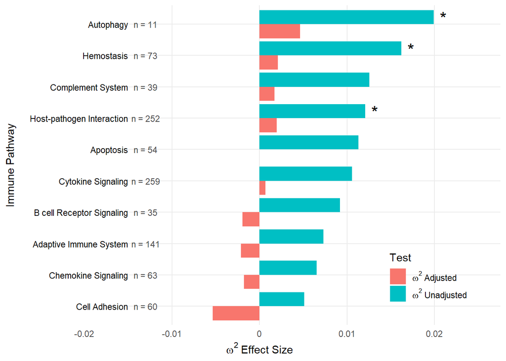

```r
library(ggplot2)

omega <- expression(omega^2~Statistic)
omegaadj <- expression(omega^2~Adjusted)
omegaunadj <- expression(omega^2~Unadjusted)

ggplot(results_long, aes(x = Effect_Size, y = reorder(Pathway, Effect_Size), fill = Test)) +
  geom_bar(stat = "identity", position = "dodge") +

  geom_vline(xintercept = c(-0.02),
             color = "white",
             linewidth = 0.5) +

  annotate("rect",
           xmin = -Inf, xmax = -0.015,
           ymin = -Inf, ymax = Inf,
           fill = "white") +

  geom_text(aes(label = sig_label), vjust = 0.01, hjust = -0.9, size = 6) +

  geom_text(
    data = count_df,
    aes(x = -0.015, y = Pathway, label = Pathway),
    hjust = 1,
    size = 3,
    color = "black",
    inherit.aes = FALSE
  ) +

  geom_text(
    data = count_df,
    aes(x = label_x_position, y = Pathway, label = paste0("n = ", n)),
    hjust = 0.5,
    size = 3,
    color = "gray30",
    inherit.aes = FALSE
  ) +


  scale_fill_manual(values = c("cyan3", "salmon")) +

  scale_fill_discrete(labels=c(omegaadj, omegaunadj)) +

  scale_x_continuous(
    limits = c(-0.025, 0.025),
    breaks = c(-0.02, -0.01, 0, 0.01, 0.02),
    labels = c("-0.02", "-0.01", "0", "0.01", "0.02")
  ) +

  coord_cartesian(clip = "off") +

  labs(x = expression(omega^2 ~ "Effect Size"), y = "Immune Pathway") +
  theme_minimal() +
  theme(
    axis.text.y = element_blank(),
    panel.grid.minor = element_blank(),
    legend.position = c(0.85, 0.15)
  )
```

# 4 Conclusions

This extension of the $W_d^*$ test allows adjustment of the test statistics for additional covariates. In this example, we compared the unadjusted and adjusted $W_d^*$ effect sizes for the association between BMI categories and immune pathway expression in preinvasive colorectal lesions. The visualization above provides motivation to adjust for additional variables; The $W_d^*$ $ω²$ effect sizes vary in magnitude between unadjusted and adjusted analyses. This may suggest that at least some of the variability in immune pathway expression between BMI categories may be explained or confounded by one or more of the adjustment covariates (age, sex, histologic type). Therefore, an adjusted test statistic allows for a less biased estimation for the association between BMI categories and immune pathway expression.

# 5 Tips

1. The $W_d^*$ test requires that your predictor variable be a factor, an error will be returned otherwise. The function as.factor() is an easy way to convert the predictor variable into a factor if it is not already.
2. The function a.dist() in the WdStar package automatically calculates Euclidean distances, so specifying distance measure is not necessary unless another distance metric is preferred.